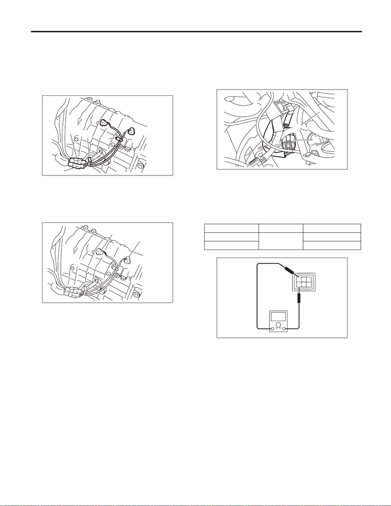

6MT(TY85)-40

Back-up Light Switch

MANUAL TRANSMISSION AND DIFFERENTIAL

11.Back-up Light Switch

A: REMOVAL

1) Remove the manual transmission assembly

AL, Manual Transmission Assembly.>

2) Disconnect the back-up light switch connector.

3) Disconnect the back-up light switch.

B: INSTALLATION

1) Install the back-up light switch.

NOTE:

Use a new gasket.

Tightening torque:

32 N·m (3.3 kgf-m, 23.6 ft-lb)

2) Connect the back-up light switch connector.

3) Install the manual transmission assembly to the

vehicle. <Ref. to 6MT(TY85)-33, INSTALLATION,

Manual Transmission Assembly.>

C: INSPECTION

1) Disconnect the ground cable from battery.

2) Remove the intercooler. <Ref. to IN(STI)-13,

REMOVAL, Intercooler.>

sis harness.

4) Measure the resistance between the back-up

tion, replace the back-up light switch.

(A) Back-up light switch connector (gray)

(B) Neutral position switch connector (brown)

(C) Clip

(A) Back-up light switch

(B) Neutral position switch

MT-03067

(A)

(B)

(C)

(C)

MT-03068

(A)

(B)

(A) Transmission harness connectors

(B) Pitching stopper

Gear shift position Terminal No. Standard

Back position

3 and 6

Less than 1 Ω

Other positions 1 MΩ or more

MT-01741

(A)

(B)

2

1

4

3

MT-00946